# PA1_template

Giulio Ruggeri

2022-12-02

## Project description

It is now possible to collect a large amount of data about personal movement using activity monitoring devices such as a Fitbit, Nike Fuelband, or Jawbone Up. These type of devices are part of the “quantified self” movement – a group of enthusiasts who take measurements about themselves regularly to improve their health, to find patterns in their behavior, or because they are tech geeks. But these data remain under-utilized both because the raw data are hard to obtain and there is a lack of statistical methods and software for processing and interpreting the data.

This assignment makes use of data from a personal activity monitoring device. This device collects data at 5 minute intervals through out the day. The data consists of two months of data from an anonymous individual collected during the months of October and November, 2012 and include the number of steps taken in 5 minute intervals each day.

The data for this assignment can be downloaded from the course web site:

Dataset: Activity monitoring data [52K]

The variables included in this dataset are:

steps: Number of steps taking in a 5-minute interval (missing values are coded as NA)

date: The date on which the measurement was taken in YYYY-MM-DD format

interval: Identifier for the 5-minute interval in which measurement was taken

The dataset is stored in a comma-separated-value (CSV) file and there are a total of 17,568 observations in this dataset.

## Loading packages

```r
library(ggplot2)
library(ggthemes)
```

## reading data, previoulsy saved on internal directory

```r
data <- read.csv("~/Learning/2022 - Data Science Course - Cursera/Module 5/Week 2/repdata_data_activity/activity.csv")

data_tyde <- data[!is.na(data$steps),] #remove NA values for steps
```

## calculation of total number of steps per day

```r
steps_day <- tapply(data_tyde$steps, data_tyde$date, sum) #tapply function
steps_date <- unique(data_tyde$date)
steps_mean <- mean(steps_day) #mean
steps_median <- median(steps_day) #median
```

```r
steps_mean
```

```
## [1] 10766.19
```

```r
steps_median
```

```
## [1] 10765
```

## plot 1:

histogram to show the frequency of the steps number per day

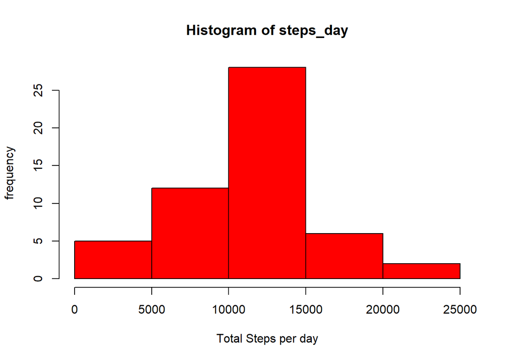

```r
plot1 <-hist(steps_day, col = "red", xlab = "Total Steps per day", ylab = "frequency")
```

```r
dev.copy(png, file="Plot1.png") #save the plot in png, 480x480 pixels by default
```

```r
dev.off() #close the saving session
```

## 5 minutes Intervals

calculate the averaged of steps, along the 5 minutes interval and create a new data frame with this quantity for each interval along the day

```r
step_a_int <- aggregate(data_tyde$steps, by = list(data_tyde$interval),
                                  FUN = mean, na.rm = TRUE)
colnames(step_a_int) <- c("interval", "av_steps")
```

## plot 2: time plot of the steps per number of intervals

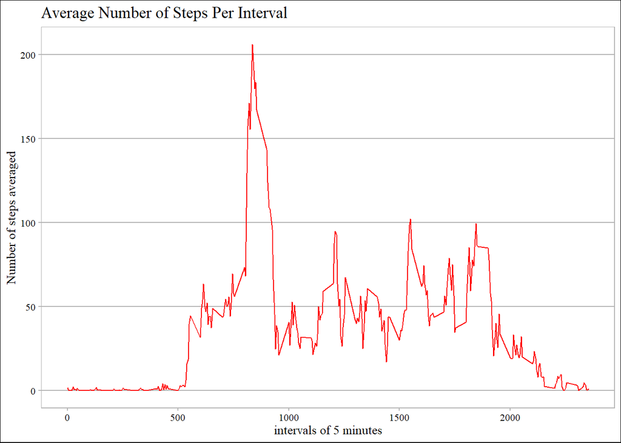

```r
plot2 <- ggplot(step_a_int, mapping = aes(interval, av_steps)) +
        geom_line(col = "red") +
        xlab("intervals of 5 minutes") +
        ylab("Number of steps averaged") +
        ggtitle("Average Number of Steps Per Interval") +
        theme_calc(base_family = "serif")


print(plot2)
```

```r
dev.copy(png, file="Plot2.png") #save the plot in png, 480x480 pixels by default
```

```r
dev.off() #close the saving session
```

## calculation of the interval with maximum steps

```r
maximum_steps <-step_a_int[which.max(step_a_int$av_steps), 1]

maximum_steps
```

```
## [1] 835
```

## calculation of the missing values and finding their index

```r
n_missing <- sum(is.na(data$steps)) #tot missing values
NA_values_index <- is.na(data$steps) #logic vector of TRUE missing values index
Index_vector <- grep("TRUE", NA_values_index) #array with the indeces of missing values
NA_date <- data$date[Index_vector] #corresponding dates of the missing values
NA_new_steps <- step_a_int$av_steps[match(data$interval, step_a_int$interval, nomatch = 0)] #corresponding average steps of these missing dates

n_missing
```

```
## [1] 2304
```

## sobstitute the average steps of these missing values’s dates and recreate the dataset

```r
data_filled <- transform(data, steps = ifelse(is.na(data$steps), yes = NA_new_steps, no = data$steps))

Na_newdataset <- sum(is.na(data_filled$steps)) #test the new data set -> if the value is 0, no missing values!
```

## plot 3: make a similar histogram of plot 1 to check differences

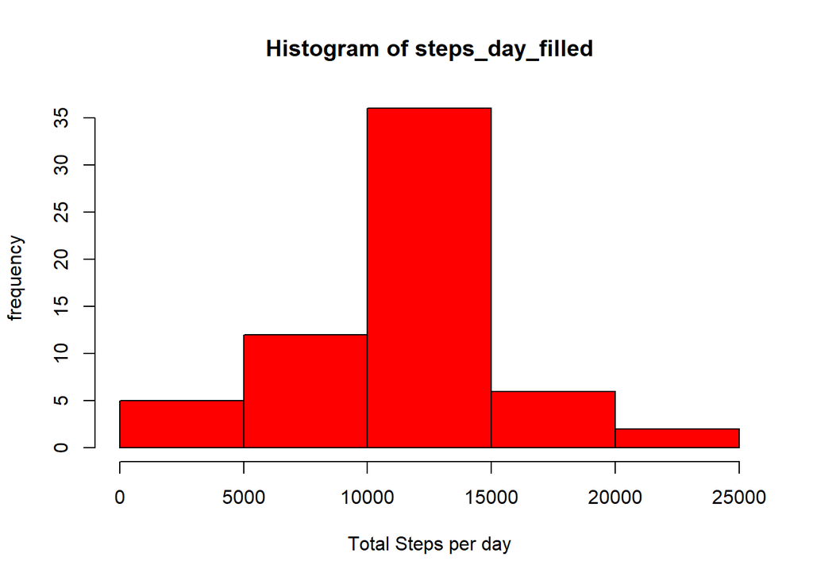

```r
steps_day_filled <- tapply(data_filled$steps, data_filled$date, sum)

date_filled <- unique(data_filled$date)
steps_day_filled_df <- data.frame(steps_day_filled, date_filled)


plot3 <-hist(steps_day_filled, col = "red", xlab = "Total Steps per day", ylab = "frequency")
```

```r
dev.copy(png, file="Plot3.png") #save the plot in png, 480x480 pixels by default
```

```r
dev.off() #close the saving session
```

```r
steps_mean_filled <- mean(steps_day_filled) #mean
steps_median_filled <- median(steps_day_filled) #median
```

```r
steps_mean_filled
```

```
## [1] 10766.19
```

```r
steps_median_filled
```

```
## [1] 10766.19
```

## check wether there are differences in the steps patterns along the intervals, during week vs weekend days

```r
data_filled$date <- weekdays(strptime(data_filled$date, format="%Y-%m-%d")) #update the format to get the name of the day, in a way to distinguish the weekend days

#apply a if structure to all the data, to distinguish between week and weekend days
data_filled$dayType <- sapply(data_filled$date, function(x) {

        if(x == "Samstag" | x == "Sonntag")
        {y <- "Weekend"}
        else {y <- "Weekday"}
        y
})
```

## plot4: the time line plots, similar to plot 2, but with both week and weekend days time line

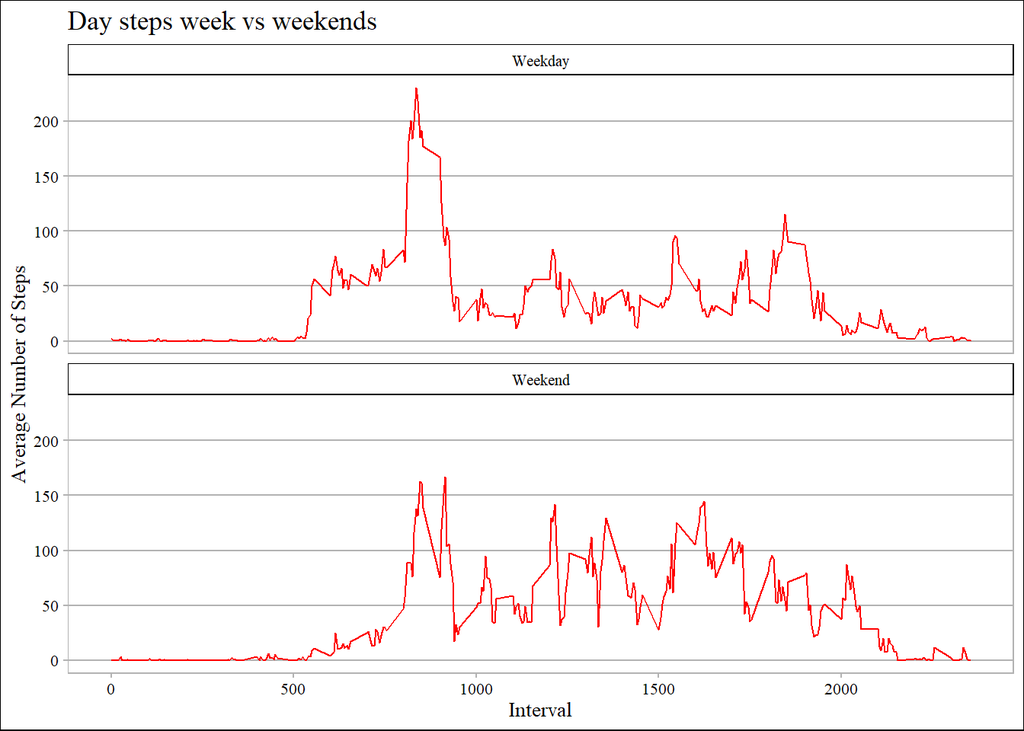

```r
step_a_int <- aggregate(data_filled$steps, by = list(data_filled$interval, data_filled$dayType),
                        FUN = mean, na.rm = TRUE)
colnames(step_a_int) <- c("interval","dayType", "av_steps")


plot4 <- ggplot(step_a_int, aes(x = interval, y = av_steps, color = dayType )) +
        geom_line(col="red") +
        ggtitle("Day steps week vs weekends") +
        xlab("Interval") +
        ylab("Average Number of Steps") +
        facet_wrap(~dayType, ncol = 1, nrow=2) +
        theme_calc(base_family = "serif")


print(plot4)
```

```r
dev.copy(png, file="Plot4.png") #save the plot in png, 480x480 pixels by default
```

```r
dev.off() #close the saving session
```